# Ford Gobike Data Exploration

## By Yasser A.Rahman

> This Dataset is provided for Ford gobike trip data in 2019 for Sab Fransisco city. it has around 183K entries. It's one of the innovative solutions in very congested cities.

### Exploring the Dataset

|  | duration_sec | start_time | end_time | start_station_id | start_station_name | start_station_latitude | start_station_longitude | end_station_id | end_station_name | end_station_latitude | end_station_longitude | bike_id | user_type | member_birth_year | member_gender | bike_share_for_all_trip |
| --- | --- | --- | --- | --- | --- | --- | --- | --- | --- | --- | --- | --- | --- | --- | --- | --- |
| count | 183412.000000 | 183412 | 183412 | 183215.000000 | 183215 | 183412.000000 | 183412.000000 | 183215.000000 | 183215 | 183412.000000 | 183412.000000 | 183412.000000 | 183412 | 175147.000000 | 175147 | 183412 |
| unique | NaN | 183401 | 183397 | NaN | 329 | NaN | NaN | NaN | 329 | NaN | NaN | NaN | 2 | NaN | 3 | 2 |
| top | NaN | 2019-02-01 13:40:09.4920 | 2019-02-20 09:40:38.4500 | NaN | Market St at 10th St | NaN | NaN | NaN | San Francisco Caltrain Station 2 (Townsend St... | NaN | NaN | NaN | Subscriber | NaN | Male | No |
| freq | NaN | 2 | 2 | NaN | 3904 | NaN | NaN | NaN | 4857 | NaN | NaN | NaN | 163544 | NaN | 130651 | 166053 |
| mean | 726.078435 | NaN | NaN | 138.590427 | NaN | 37.771223 | -122.352664 | 136.249123 | NaN | 37.771427 | -122.352250 | 4472.906375 | NaN | 1984.806437 | NaN | NaN |
| std | 1794.389780 | NaN | NaN | 111.778864 | NaN | 0.099581 | 0.117097 | 111.515131 | NaN | 0.099490 | 0.116673 | 1664.383394 | NaN | 10.116689 | NaN | NaN |
| min | 61.000000 | NaN | NaN | 3.000000 | NaN | 37.317298 | -122.453704 | 3.000000 | NaN | 37.317298 | -122.453704 | 11.000000 | NaN | 1878.000000 | NaN | NaN |
| 25% | 325.000000 | NaN | NaN | 47.000000 | NaN | 37.770083 | -122.412408 | 44.000000 | NaN | 37.770407 | -122.411726 | 3777.000000 | NaN | 1980.000000 | NaN | NaN |
| 50% | 514.000000 | NaN | NaN | 104.000000 | NaN | 37.780760 | -122.398285 | 100.000000 | NaN | 37.781010 | -122.398279 | 4958.000000 | NaN | 1987.000000 | NaN | NaN |
| 75% | 796.000000 | NaN | NaN | 239.000000 | NaN | 37.797280 | -122.286533 | 235.000000 | NaN | 37.797320 | -122.288045 | 5502.000000 | NaN | 1992.000000 | NaN | NaN |
| max | 85444.000000 | NaN | NaN | 398.000000 | NaN | 37.880222 | -121.874119 | 398.000000 | NaN | 37.880222 | -121.874119 | 6645.000000 | NaN | 2001.000000 | NaN | NaN |

### Dataset Structure

> The Dataset has 183,412 rows (each one is equivalent to a single trip) and 16 features associated with each trip. All featres are quite self explanatory.

> the last column "bike_share_for_all_trip", which tracks members who are enrolled in the Bike Share for All program for low-income residents.

### Main Features of interest

> we shall consider here that trip duration as the main variable (dependant variable or target) of this dataset. I have chosen to check the inter relationships among age, gender and user types on the target variable.

## Univariate Exploration

> In this section, I will investigate the distribution of the 4 selected fatures in the dataset eash one separately. The main outcome of this step is to scrutinize the 4 features and check if any wrangling stpes are need or no.

### Target Feature Distribution (Trip Duration)

> what is the shape of trip duration distribution?

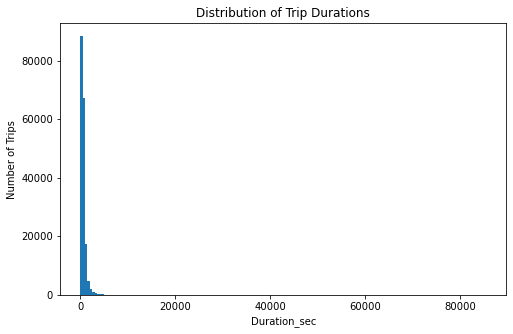

> Trip duration distribution has shown a long tail behaviuor. This indicates a big amount of outliers present in the dataset.

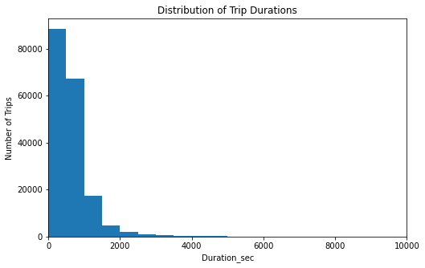

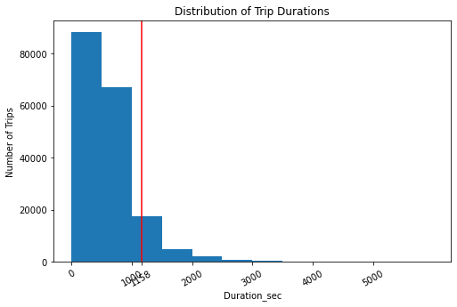

### Insight (1)

> **90% of rides are with duration less than 1158 seconds (19 minutes)**

###### The Histogram of the trip duration is right skewed. we have dropped the records of trip duration higher than 6000 second. The resulted histogram has shown a long tail too. In order to investigate the trip duration further, we need to make a logarithmic transfrmation for the x-axis as will be seen in the next step

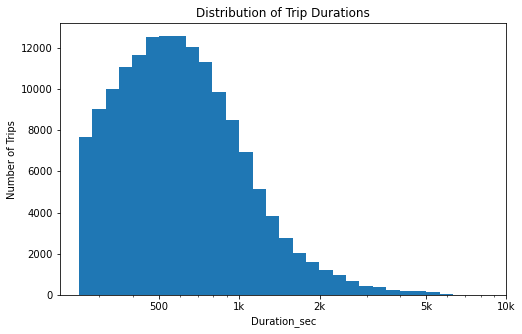

The distribution looks a unimodal one with mode around 600 sec (10 minutes ride) and corresponding frequency of a value around 12K. Then it falls gradually till it reaches 2000 second (33 minutes ride)

### Insight (2)

> **The most frequent rides in San Fransisco Bike Share is with duration of 10 minutes.**

### Age Feature Distribution

> Does Age has any effect on the trip duration?

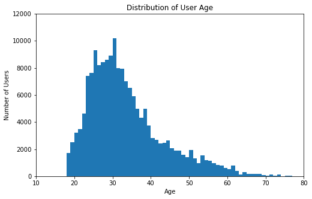

### Gender Feature Distribution

> Is there any gender dependency on trip duration?

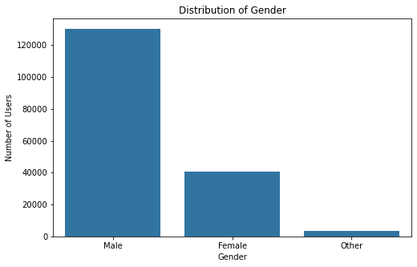

### User Type Feature Distribution

> Does subscriber user have a higher trip duration than casual one?

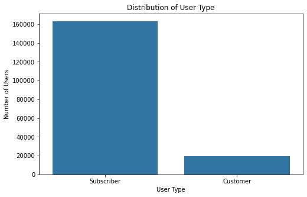

### Insight (5)

> **Subscribers have completed more than eight times the number of rides compared to customers who hold single-use or day-ride passes.**

## Bivariate Exploration

> We are going here to consider the variation between the main target variable (Trip Duration) and the 3 chosen faetures: age, user type, and gender.

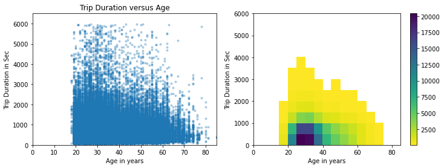

### Insight (6)

> It's quite clear that there is an inversely proportional relationship between age and trip duration as it can be observed from the declining distribution of trip duration over age in years.  
> it's also very obviuos that the main age interval of riders arwe between 20 and 40 years. the peak of that age interval exists on 25-30 years old.

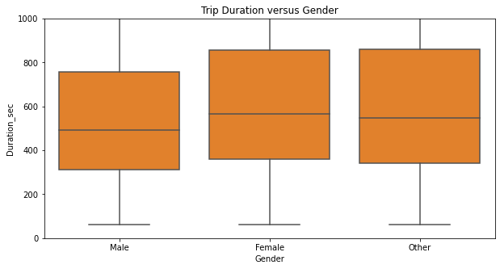

### Insight (7)

> **This is an intersting insight form this dataset. Female and other have a higher median of trip duration than Male.**

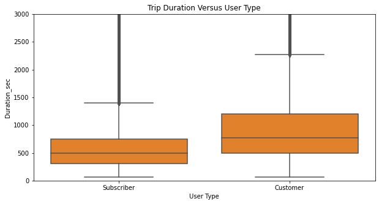

### Insight (8)

> **This is also an intersting insight form this dataset. Casual customers have a higher median of trip duration (1.5x times) than regular subscribers.**

## Multivariate Exploration

> In this section, we shall investigate two relationships:
> - Between trip duration, age and gender
> - Between trip duration, age and user type

[output not shown]

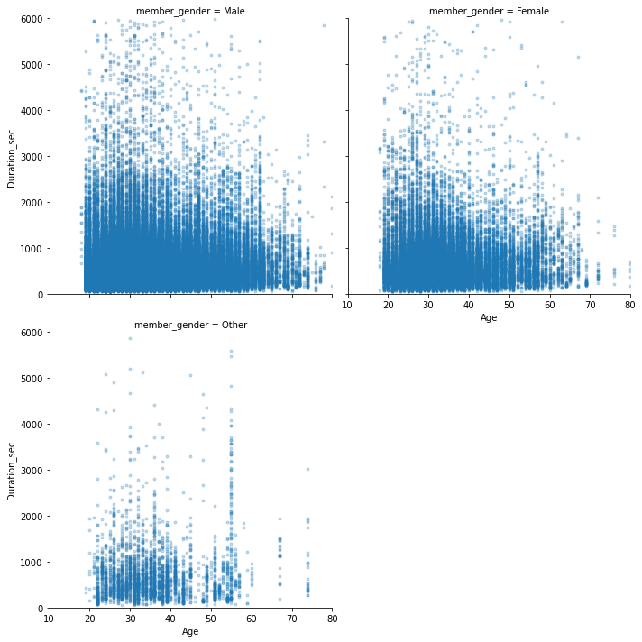

### Insight (9)

> **There is no signifcant difference between male and female regarding the age effect on the rate of rides (same age group of both male and female are showing identical behaviuor)**

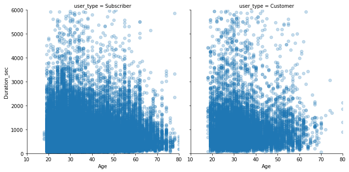

### Insight (10)

> **The user type does not have any significant effect on the age profile of riders (same age group in both custmer and subscriber shows similar dependency with duratio trip). But, on the other hand, Customer type has a gap in the age group from 70-80 years old compared to Subscriber type.**

## Conclusion

[output not shown]